# Python Project - Prosper Loan Dataset¶

## Introduction

The Prosper Loan Dataset is a collection of data from the prosper lending online business, The dataset provide insightful information on loan status,occupation, borrowerstate, loandate, loanrate, creditgrade, monthlyincome, investors, percentfunded etc. It also provide information on fullfilled and unfilled application, credit risk assessment, borrowers behaviour.

## Preliminary Wrangling

```python
import numpy as np
import pandas as pd
import matplotlib.pyplot as plt
import seaborn as sns
```

```python
df = pd.read_csv('prosper loan.csv')
```

```python
df
```

|  | ListingKey | ListingNumber | ListingCreationDate | CreditGrade | Term | LoanStatus | ClosedDate | BorrowerAPR | BorrowerRate | LenderYield | ... | LP_ServiceFees | LP_CollectionFees | LP_GrossPrincipalLoss | LP_NetPrincipalLoss | LP_NonPrincipalRecoverypayments | PercentFunded | Recommendations | InvestmentFromFriendsCount | InvestmentFromFriendsAmount | Investors |
| --- | --- | --- | --- | --- | --- | --- | --- | --- | --- | --- | --- | --- | --- | --- | --- | --- | --- | --- | --- | --- | --- |
| 0 | 1021339766868145413AB3B | 193129 | 09:29.3 | C | 36 | Completed | 14/08/2009 00:00 | 0.16516 | 0.1580 | 0.1380 | ... | -133.18 | 0.0 | 0.0 | 0.0 | 0.0 | 1.0 | 0 | 0 | 0.0 | 258 |
| 1 | 10273602499503308B223C1 | 1209647 | 28:07.9 | NaN | 36 | Current | NaN | 0.12016 | 0.0920 | 0.0820 | ... | 0.00 | 0.0 | 0.0 | 0.0 | 0.0 | 1.0 | 0 | 0 | 0.0 | 1 |
| 2 | 0EE9337825851032864889A | 81716 | 00:47.1 | HR | 36 | Completed | 17/12/2009 00:00 | 0.28269 | 0.2750 | 0.2400 | ... | -24.20 | 0.0 | 0.0 | 0.0 | 0.0 | 1.0 | 0 | 0 | 0.0 | 41 |
| 3 | 0EF5356002482715299901A | 658116 | 02:35.0 | NaN | 36 | Current | NaN | 0.12528 | 0.0974 | 0.0874 | ... | -108.01 | 0.0 | 0.0 | 0.0 | 0.0 | 1.0 | 0 | 0 | 0.0 | 158 |
| 4 | 0F023589499656230C5E3E2 | 909464 | 38:39.1 | NaN | 36 | Current | NaN | 0.24614 | 0.2085 | 0.1985 | ... | -60.27 | 0.0 | 0.0 | 0.0 | 0.0 | 1.0 | 0 | 0 | 0.0 | 20 |
| ... | ... | ... | ... | ... | ... | ... | ... | ... | ... | ... | ... | ... | ... | ... | ... | ... | ... | ... | ... | ... | ... |
| 113932 | E6D9357655724827169606C | 753087 | 55:02.7 | NaN | 36 | Current | NaN | 0.22354 | 0.1864 | 0.1764 | ... | -75.58 | 0.0 | 0.0 | 0.0 | 0.0 | 1.0 | 0 | 0 | 0.0 | 1 |
| 113933 | E6DB353036033497292EE43 | 537216 | 42:55.3 | NaN | 36 | FinalPaymentInProgress | NaN | 0.13220 | 0.1110 | 0.1010 | ... | -30.05 | 0.0 | 0.0 | 0.0 | 0.0 | 1.0 | 0 | 0 | 0.0 | 22 |
| 113934 | E6E13596170052029692BB1 | 1069178 | 49:12.7 | NaN | 60 | Current | NaN | 0.23984 | 0.2150 | 0.2050 | ... | -16.91 | 0.0 | 0.0 | 0.0 | 0.0 | 1.0 | 0 | 0 | 0.0 | 119 |
| 113935 | E6EB3531504622671970D9E | 539056 | 18:26.6 | NaN | 60 | Completed | 13/08/2013 00:00 | 0.28408 | 0.2605 | 0.2505 | ... | -235.05 | 0.0 | 0.0 | 0.0 | 0.0 | 1.0 | 0 | 0 | 0.0 | 274 |
| 113936 | E6ED3600409833199F711B7 | 1140093 | 27:37.7 | NaN | 36 | Current | NaN | 0.13189 | 0.1039 | 0.0939 | ... | -1.70 | 0.0 | 0.0 | 0.0 | 0.0 | 1.0 | 0 | 0 | 0.0 | 1 |

113937 rows × 81 columns

```python
df.info()
```

```
<class 'pandas.core.frame.DataFrame'>
RangeIndex: 113937 entries, 0 to 113936
Data columns (total 81 columns):
 #   Column                               Non-Null Count   Dtype
---  ------                               --------------   -----
 0   ListingKey                           113937 non-null  object
 1   ListingNumber                        113937 non-null  int64
 2   ListingCreationDate                  113937 non-null  object
 3   CreditGrade                          28953 non-null   object
 4   Term                                 113937 non-null  int64
 5   LoanStatus                           113937 non-null  object
 6   ClosedDate                           55089 non-null   object
 7   BorrowerAPR                          113912 non-null  float64
 8   BorrowerRate                         113937 non-null  float64
 9   LenderYield                          113937 non-null  float64
```

[output cut: 73 more lines]

```python
df.shape
```

```
(113937, 81)
```

## What is the structure of your dataset?

The prosper loan dataset consists of 113937 rows and 81 columns. datatypes: 3 bools, 17 object, 12 integer(int64), 49 float(float64). memory usage: 68.1+ MB The dataset is a comprehensive collection of loan related information containing the borrower details, loan attributes and various financial and demographic variables.

## What is/are the main feature(s) of interest in your dataset?

Features of interest in prosper loan dataset

1. Loan status
2. Loan amount
3. interest rate
4. investors
5. datecredit pulled
6. monthlyloan payment

## What features in the dataset do you think will help support your investigation into your feature(s) of interest?

Features are

1. Borrower Demographic
2. prosper rating
3. Loan term
4. Total prosper loan

```python
df.columns = df.columns.str.lower()
```

```python
df.drop(['lp_collectionfees','lp_grossprincipalloss','lp_netprincipalloss','lp_nonprincipalrecoverypayments','recommendations', 'investmentfromfriendsamount','investmentfromfriendscount','listingkey','creditgrade'], inplace=True, axis=1)
```

```python
df_unique = df.drop_duplicates()
```

```python
df_with_empty_rows = df.dropna(axis=0)
```

```python
df.head(2)
```

|  | listingnumber | listingcreationdate | term | loanstatus | closeddate | borrowerapr | borrowerrate | lenderyield | estimatedeffectiveyield | estimatedloss | ... | loanoriginationdate | loanoriginationquarter | memberkey | monthlyloanpayment | lp_customerpayments | lp_customerprincipalpayments | lp_interestandfees | lp_servicefees | percentfunded | investors |
| --- | --- | --- | --- | --- | --- | --- | --- | --- | --- | --- | --- | --- | --- | --- | --- | --- | --- | --- | --- | --- | --- |
| 0 | 193129 | 09:29.3 | 36 | Completed | 14/08/2009 00:00 | 0.16516 | 0.158 | 0.138 | NaN | NaN | ... | 12/09/2007 00:00 | Q3 2007 | 1F3E3376408759268057EDA | 330.43 | 11396.14 | 9425.0 | 1971.14 | -133.18 | 1.0 | 258 |
| 1 | 1209647 | 28:07.9 | 36 | Current | NaN | 0.12016 | 0.092 | 0.082 | 0.0796 | 0.0249 | ... | 03/03/2014 00:00 | Q1 2014 | 1D13370546739025387B2F4 | 318.93 | 0.00 | 0.0 | 0.00 | 0.00 | 1.0 | 1 |

2 rows × 72 columns

## Univarite Exploration

### Question 1: what is the origination of the loan quarter in the prosper loan dataset?

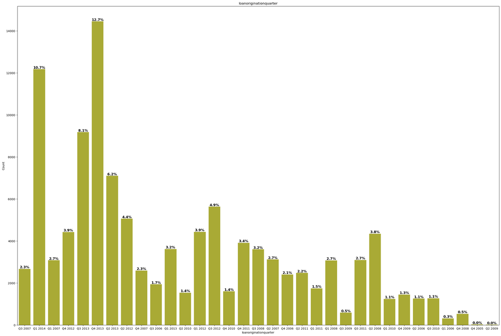

```python
plt.figure(figsize=(30,20))
ax = sns.countplot(x='loanoriginationquarter', data=df, color=sns.color_palette()[8])

plt.title('loanoriginationquarter')
plt.xlabel('loanoriginationquarter')
plt.ylabel('Count')

total_count = len(df)

for container in ax.containers:
    for bar in container:
        count = bar.get_height()
        percent = (count * 100) / total_count
        ax.annotate(f'{percent:.1f}%', xy=(bar.get_x() + bar.get_width() / 2, bar.get_height()),
                    ha='center', va='bottom', fontsize=12, color='black',fontweight='bold')
```

#### comment

The loanoriginationquarter in the analysis shows the different years and quarters of the origin of prosper loan and also shows the year and quarter that have the highest lending value. the origination of prosper loan quarter in the dataset was in 2005 Q4 and the lending value was (22), in 2013 Q4 they have the highest lending value (14450), followed by 2014 Q1 they have (12172) and so on in the dataset.

### what are the different loan status?

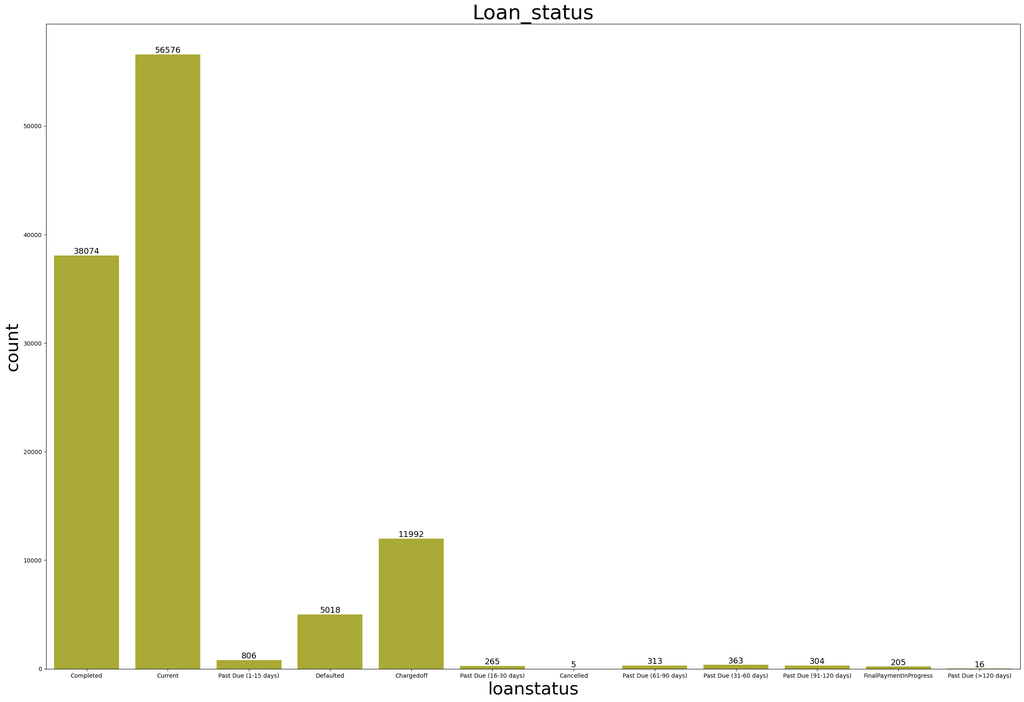

```python
sns.countplot(data=df, x='loanstatus',)
plt.title('Loan_status', size=35)
fig = plt.gcf()
fig.set_size_inches(30, 20)
plt.xlabel('loanstatus', size=30)
plt.ylabel('count', size=30)

ax = sns.countplot(x='loanstatus', data=df,color=sns.color_palette()[8])
ax.bar_label(ax.containers[1], fmt='%d',fontsize=14,fontweight='light')

plt.show()
```

#### comment

The loanstatus in the dataset shows the current status of the loan, if the client has defaulted, currently paying, chargedoff, cancelled, past due, or completed payment

### what is the employment status of the prosper loan dataset?

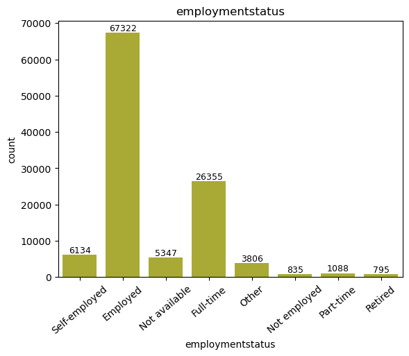

```python
sns.countplot(data=df, x='employmentstatus')
plt.xticks(rotation=40)
plt.title('employmentstatus', size=12)
plt.xlabel('employmentstatus', size=10)
plt.ylabel('Count', size=10)

ax = sns.countplot(x='employmentstatus', data=df,color=sns.color_palette()[8])
ax.bar_label(ax.containers[0], fmt='%d',fontsize=9,fontweight='light')

plt.show()
```

#### comment

The Employment status in the prosper loan dataset shows that most of the borrowers are employed.

```python
sns.countplot(data=df, x='monthlyloanpayment',);
plt.title('monthlyloanpayment', size=35);
fig.set_size_inches(30, 20)
plt.xlabel('count', size=15)
plt.ylabel('monthlyloanpayment', size=15)

ax = sns.countplot(x='monthlyloanpayment', data=df,color=sns.color_palette()[8])
ax.bar_label(ax.containers[0], fmt='%d',fontsize=14,fontweight='light')

plt.show()
```

[output not shown]